# 02-Classification

```r
# read in the data
stackoverflow <- read_rds(here::here("materials/data/stackoverflow.rds"))

# split the data
set.seed(100) # Important!
so_split <- initial_split(stackoverflow, strata = remote)
so_train <- training(so_split)
so_test  <- testing(so_split)
```

# Your Turn 1

Get in your teams. Have one member think of an animal; other members try to guess it by asking yes/no questions about it. Go!

Write down how many questions it takes your team.

# Your Turn 2

In your teams, discuss what qualities made for a good versus a bad question.

# Your Turn 3

Using the `so_train` and `so_test` datasets, how many individuals in our training set are remote? How about in the testing set?

```r
so_train %>%
  count(remote)
```

```
## # A tibble: 2 x 2
## # Groups:   remote [2]
##   remote         n
##   <fct>      <int>
## 1 Remote       432
## 2 Not remote   432
```

```r
so_test %>%
  count(remote)
```

```
## # A tibble: 2 x 2
## # Groups:   remote [2]
##   remote         n
##   <fct>      <int>
## 1 Remote       143
## 2 Not remote   143
```

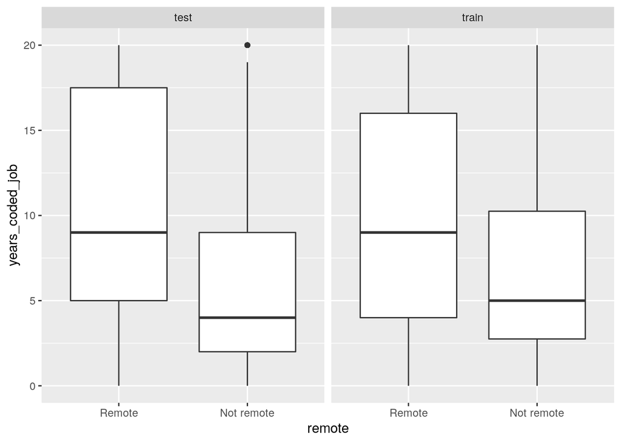

```r
so_all_tmp <- bind_rows(
  so_train %>% mutate(dataset = "train"),
  so_test %>% mutate(dataset = "test")
)
ggplot(so_all_tmp, aes(remote, years_coded_job)) +
  geom_boxplot() +
  facet_grid(cols = vars(dataset))
```

# Your Turn 4

Fill in the blanks. Use `fit_split()` and `collect_predictions()` to

1. Fit a classification tree model with the formula `remote ~ years_coded_job + salary`
2. Look at the predictions you’ve collected- which variable corresponds to the predictions? What kind of variable is it?
3. Keep `set.seed(100)` at the start of your code.

*Hint: Be sure to remove every `_` before running the code!*

```r
tree_spec <-
  decision_tree() %>%
  set_engine(engine = "rpart") %>%
  set_mode("classification")

tree_fit <- fit_split(formula = remote ~ years_coded_job + salary,
                      model = tree_spec,
                      split = so_split)
tree_fit %>%
  collect_metrics()
```

```
## # A tibble: 2 x 3
##   .metric  .estimator .estimate
##   <chr>    <chr>          <dbl>
## 1 accuracy binary         0.671
## 2 roc_auc  binary         0.678
```

```r
tree_fit
```

```
## # Resampling results
## # Monte Carlo cross-validation (0.75/0.25) with 1 resamples
## # A tibble: 1 x 6
##   splits        id           .metrics      .notes      .predictions    .workflow
##   <list>        <chr>        <list>        <list>      <list>          <list>
## 1 <split [864/… train/test … <tibble [2 ×… <tibble [0… <tibble [286 ×… <workflo…
```

```r
tree_fit %>% tidyr::unnest(cols = .predictions)
```

```
## # A tibble: 286 x 10
##    splits id    .metrics .notes .pred_Remote `.pred_Not remo…  .row .pred_class
##    <list> <chr> <list>   <list>        <dbl>            <dbl> <int> <fct>
##  1 <spli… trai… <tibble… <tibb…        0.687            0.313     2 Remote
##  2 <spli… trai… <tibble… <tibb…        0.687            0.313    12 Remote
##  3 <spli… trai… <tibble… <tibb…        0.368            0.632    15 Not remote
##  4 <spli… trai… <tibble… <tibb…        0.368            0.632    19 Not remote
##  5 <spli… trai… <tibble… <tibb…        0.687            0.313    23 Remote
##  6 <spli… trai… <tibble… <tibb…        0.368            0.632    28 Not remote
##  7 <spli… trai… <tibble… <tibb…        0.687            0.313    38 Remote
##  8 <spli… trai… <tibble… <tibb…        0.368            0.632    46 Not remote
##  9 <spli… trai… <tibble… <tibb…        0.687            0.313    53 Remote
## 10 <spli… trai… <tibble… <tibb…        0.368            0.632    56 Not remote
## # … with 276 more rows, and 2 more variables: remote <fct>, .workflow <list>
```

# Your Turn 5

Use `collect_predictions()` and `count()` to count the number of individuals (i.e., rows) by their true and predicted remote status. In groups, answer the following questions:

1. How many predictions did we make?
2. How many times is “remote” status predicted?
3. How many respondents are actually remote?
4. How many predictions did we get right?

```r
tree_fit %>%
  collect_predictions() %>%
  count(.pred_class, remote)
```

```
## # A tibble: 4 x 3
##   .pred_class remote         n
##   <fct>       <fct>      <int>
## 1 Remote      Remote        89
## 2 Remote      Not remote    40
## 3 Not remote  Remote        54
## 4 Not remote  Not remote   103
```

```r
# or using the confusion matrix function:
tree_fit %>%
  collect_predictions() %>%
  conf_mat(truth = remote, estimate = .pred_class)
```

```
##             Truth
## Prediction   Remote Not remote
##   Remote         89         40
##   Not remote     54        103
```

```r
# to show specificity and selectivity:
fit_split(remote ~ years_coded_job + salary,
          model = tree_spec,
          split = so_split,
          metrics = metric_set(accuracy, sens, spec)) %>% # here!
  collect_metrics()
```

```
## # A tibble: 3 x 3
##   .metric  .estimator .estimate
##   <chr>    <chr>          <dbl>
## 1 accuracy binary         0.671
## 2 sens     binary         0.622
## 3 spec     binary         0.720
```

# Your Turn 6

Use `collect_predictions()` and `roc_curve` to calculate the data needed to construct the full ROC curve.

What is the threshold for achieving specificity > .75?

```r
tree_fit %>%
  collect_predictions() %>%
  roc_curve(truth = remote, estimate = .pred_Remote)
```

```
## # A tibble: 5 x 3
##   .threshold specificity sensitivity
##        <dbl>       <dbl>       <dbl>
## 1   -Inf           0           1
## 2      0.368       0           1
## 3      0.6         0.720       0.622
## 4      0.687       0.762       0.573
## 5    Inf           1           0
```

# Your Turn 7

Add a `autoplot()` to visualize the ROC AUC.

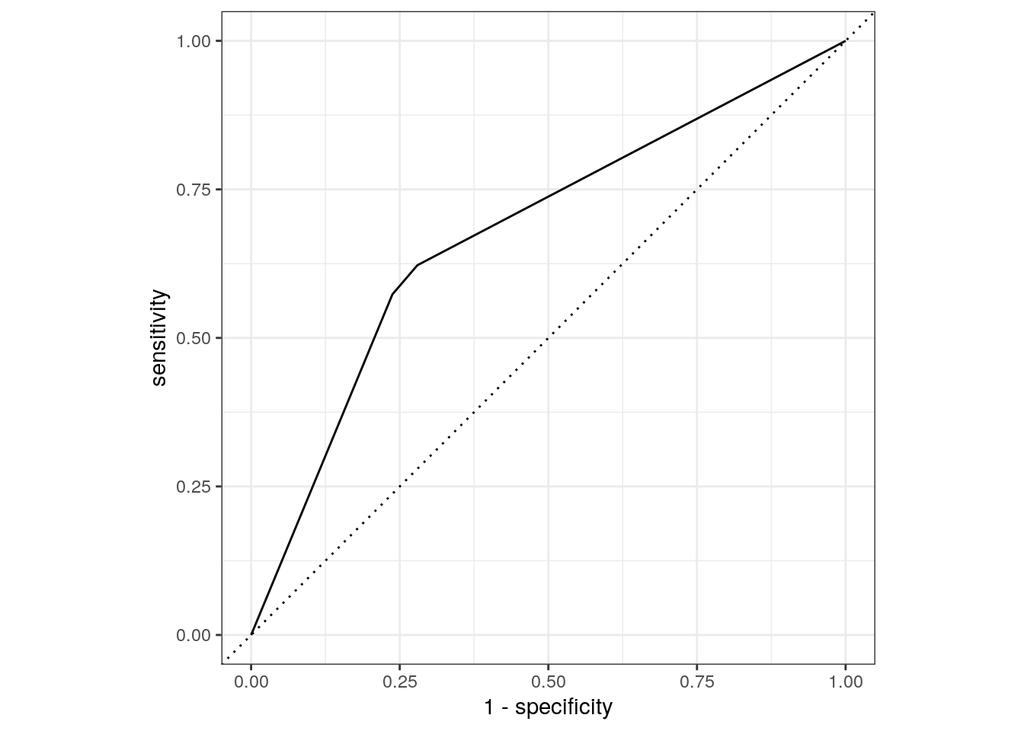

```r
# ROC curve plot
tree_fit %>%
  collect_predictions() %>%
  roc_curve(truth = remote, estimate = .pred_Remote) %>%
  autoplot()
```